# Biomarker discovery example

## Introduction

A novel enzyme-targeting inhibitor is being investigated as an anti-cancer drug. In a dose response study, it was tested for anti-proliferative effects in a diverse panel of cancer cell lines. Using data from this study, we fit dose response curves and thus assess the sensitivity of each tested cell line to the inhibitor. Then we look for potential biomarkers of drug sensitivity/resistance in gene expression data. The example shown here uses data from all available cell lines, but focusing on subsets (e.g. different tissues/lineages) is easily done using the `sample.names` argument in the main functions (`correlation.analysis` and `group.analysis`) used below.

## Dose response curves

We load the dose response data from a tab-delimited file. For each cell line we fit a curve using the [dr4pl package](https://cran.r-project.org/package=dr4pl). We then calculate the area under the curve (AUC) for each cell line as a measure of drug sensitivity (lower values mean “more sensitive”).

```r
source("../curve_fit.R")
dr.data <- read.delim(params$dose_response_file) # read tab-delimited file
curve.fits <- fit.data.long(dr.data, "cellLineName", "conc", "poc", percent=TRUE)
aucs <- sapply(curve.fits, compute.AUC)
```

We can plot the curves with IC50/AUC annotations; for example:

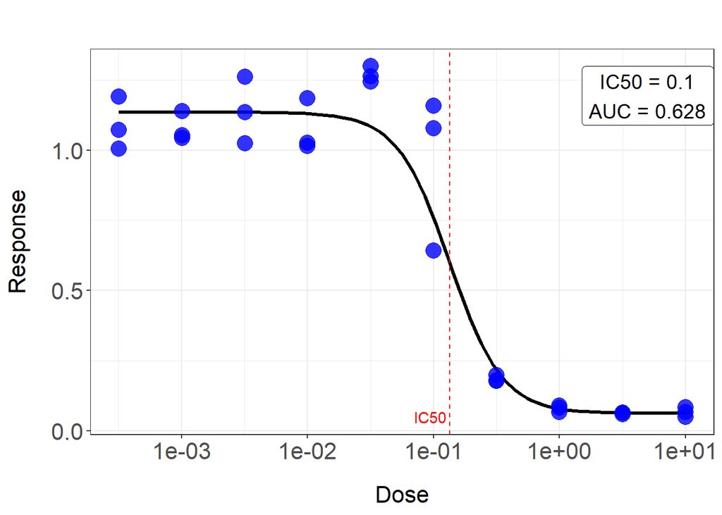

```r
plot.curve.fit(curve.fits[[which.min(aucs)]]) # plot the most sensitive (by AUC) cell line
```

### Responder classification

The tested cell lines were classified into “responder”, “intermediate”, and “non-responder” by manual inspection of the dose response curves. A low number of cell lines with “abnormal” curves were identified and will be excluded.

```r
classes <- read.csv(params$responder_classes_file, row.names=1, stringsAsFactors=TRUE)
classes <- classes[classes$class != "abnormal", , drop=FALSE] # remove "abnormal" cases
classes$class <- relevel(classes$class, ref="responder") # order classes for plotting
```

The manual classification correlates with the calculated AUCs, but does not fully recapitulate them, as the curve shapes were also taken into account:

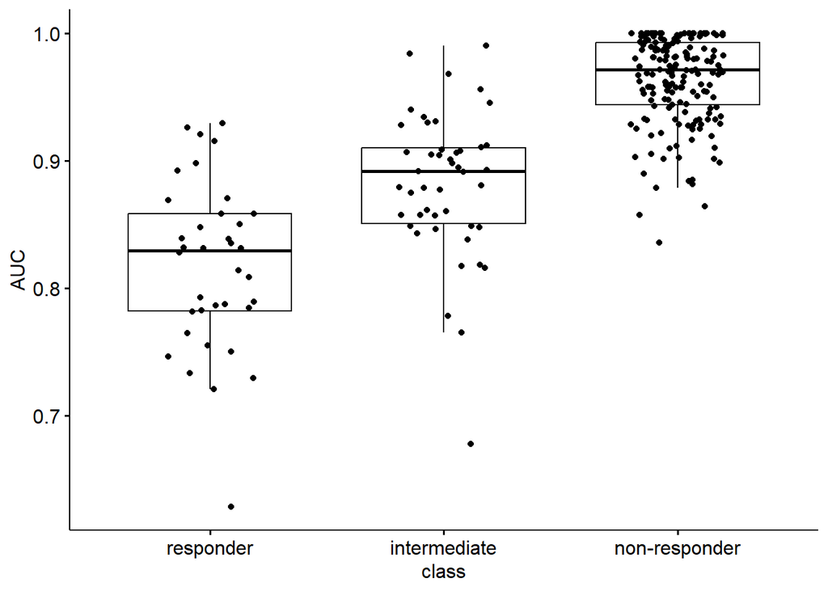

```r
library(ggpubr)
classes$AUC <- aucs[rownames(classes)] # attach AUCs for plotting
ggboxplot(classes, "class", "AUC", add="jitter")
```

## Gene expression analysis

We use publicly available gene expression data for cell lines from [Cell Model Passports](https://cellmodelpassports.sanger.ac.uk/). The [RNA-seq data file](https://cog.sanger.ac.uk/cmp/download/rnaseq_all_20220624.zip) was downloaded and TPM data extracted (“rnaseq_tpm_20220624.csv”). We prepare the dataset by generating a numeric matrix of `log2(TPM + 1)` values with cell lines in rows, genes in columns, and appropriate row/column names:

```r
library(data.table)
exp.data <- fread(params$gene_expression_file) # read large file
exp.mat <- t(as.matrix(exp.data[-(1:5), -(1:2)])) # convert to matrix
class(exp.mat) <- "numeric" # convert strings to numbers
exp.mat <- log2(exp.mat + 1) # apply transformation
rownames(exp.mat) <- as.character(exp.data[2, -(1:2)]) # use cell line names as row names
colnames(exp.mat) <- exp.data$V2[-(1:5)] # use gene symbols as column names
exp.mat <- exp.mat[, !duplicated(colnames(exp.mat))] # remove duplicate gene symbols
```

### Using cell line AUCs

We can pre-filter our data to remove cell lines without AUCs or gene expression data, and genes with low expression levels. (For convenience in this example, a mapping between cell line names used in the panel and in Cell Model Passports is already available.) Then, to find associations between expression levels of genes and AUCs of cell lines, we run a correlation-based analysis:

```r
source("../univariate.R", chdir=TRUE)
aucs <- classes$AUC; names(aucs) <- classes$CMP_name # use CMP cell line names for AUCs
common <- intersect.samples(aucs, exp.mat)
exp.mat <- filter.threshold(common$data, fraction=0.5) # require TPM >= 1 in half of samples
aucs <- common$responses # only use AUCs from cell lines with gene expression data
cors <- correlation.analysis(aucs, exp.mat)
head(cors)
```

```
##        cor.spearman cor.pearson   p.spearman    p.pearson
## DGKA     -0.2735321  -0.2937525 8.966332e-06 1.335448e-06
## AIF1L     0.2595966   0.2725270 2.503661e-05 7.288417e-06
## IFT57    -0.2548354  -0.1994710 3.516131e-05 1.027903e-03
## CTF1     -0.2505235  -0.1668710 4.758767e-05 6.027826e-03
## PPM1H     0.2501752   0.2546503 4.875514e-05 2.778703e-05
## GRPEL2    0.2486477   0.2024513 5.420421e-05 8.627917e-04
```

We can visualize the data for genes with highest (absolute) Spearman correlations:

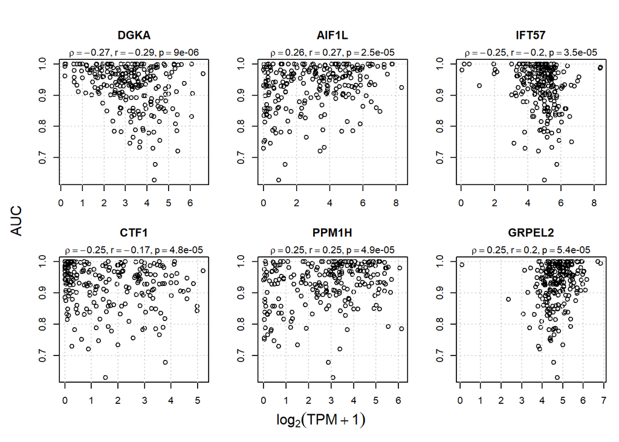

```r
plot.correlations(cors, aucs, exp.mat, 1:6, title="", xlab=expression(log[2](TPM+1)), ylab="AUC")
```

### Using responder classification

We can alternatively look for genes with different levels of expression in the responder vs. non-responder cell lines, using a group-based analysis:

```r
groups <- classes$class; names(groups) <- classes$CMP_name # use CMP cell line names for classes
groups <- na.omit(droplevels(groups, "intermediate")) # don't consider "intermediate" cell lines
stats <- group.analysis(groups, exp.mat)
head(stats)
```

```
##         n.responder n.non-responder mean.responder mean.non-responder statistic      p.value      p.adj
## KAZN             34             157      1.1356258           2.388676    1246.0 1.129803e-06 0.01513145
## ILVBL            34             157      4.6595034           5.118123    1332.5 4.842555e-06 0.03242817
## RAB3IL1          34             157      1.4078949           2.709854    1383.5 1.096368e-05 0.04894552
## EFR3B            34             157      0.7691523           1.641752    1434.0 2.394373e-05 0.06111730
## SLC4A3           34             157      1.3838124           2.674194    1439.5 2.602603e-05 0.06111730
## AGAP1            34             157      2.4127872           3.862675    1456.5 3.364998e-05 0.06111730
```

Again we can visualize the top results:

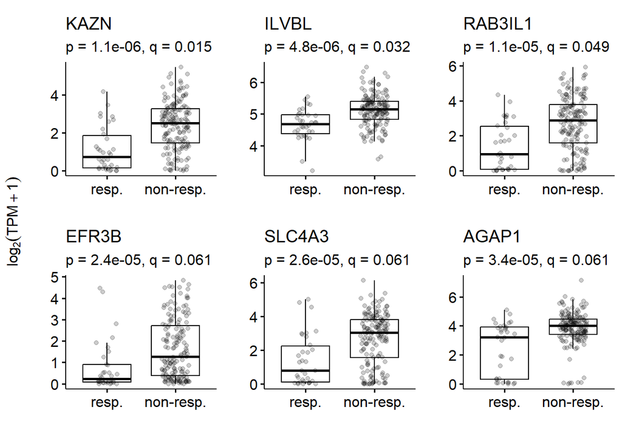

```r
levels(groups) <- sub("onder$", ".", levels(groups)) # shorten labels
plot.groups(stats, groups, exp.mat, 1:6, ylab=expression(log[2](TPM + 1)))
```

### Comparison

Although both the correlation-based and the group-based analysis aim to find associations between drug sensitivity and gene expression across cell lines, they prioritise largely different genes:

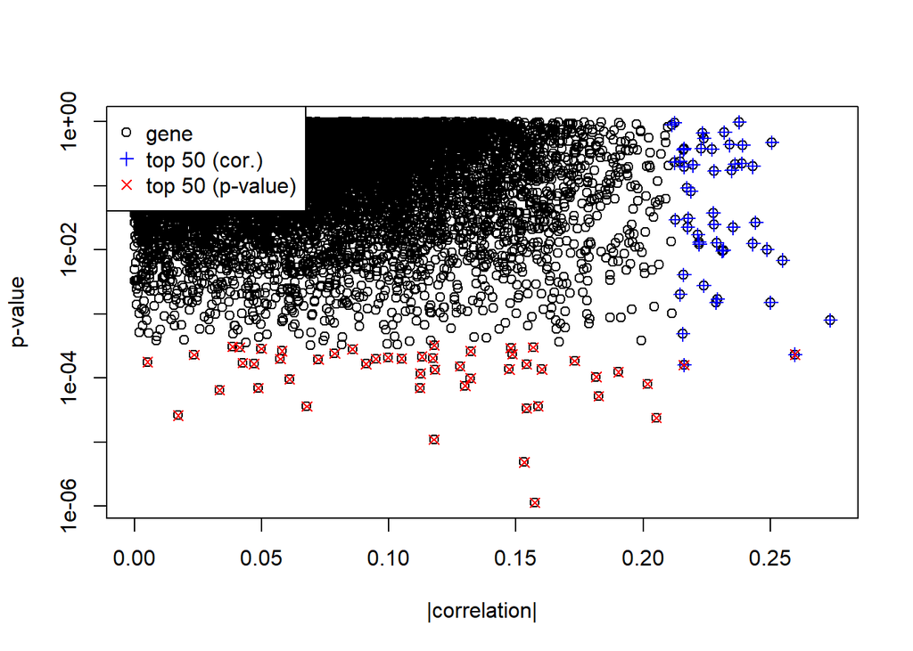

```r
merged <- data.frame(merge(cors, stats, by=0), row.names=1) # merge results from both analyses
top.cor <- rownames(cors)[1:50] # top genes by correlation
top.test <- rownames(stats)[1:50] # top genes by statistical test
plot(abs(merged$cor.spearman), merged$p.value, log="y", xlab="|correlation|", ylab="p-value")
points(abs(merged[top.cor, "cor.spearman"]), merged[top.cor, "p.value"], pch=3, col="blue")
points(abs(merged[top.test, "cor.spearman"]), merged[top.test, "p.value"], pch=4, col="red")
legend("topleft", c("gene", paste("top 50", c("(cor.)", "(p-value)"))),
       pch=c(1, 3, 4), col=c("black", "blue", "red"))
```

Among the sets of top 50 genes by (Spearman) correlation and by p-value, only 2 genes are in common. These dissimilar results highlight the value of having multiple complementary analysis options.

## Gene set enrichments

It is often useful to aggregate gene-level results to the level of gene sets (e.g. pathways, functional annotations). To this end, we define gene-wise scores such that a positive (negative) score indicates an association of drug sensitivity with higher (lower) gene expression:

```r
scores.cor <- -cors[, "cor.spearman"]; names(scores.cor) <- rownames(cors) # cor.-based analysis
scores.test <- -log10(stats$p.value) * sign(stats$mean.responder - stats$"mean.non-responder")
names(scores.test) <- rownames(stats) # group-based analysis
```

We can then easily run gene set enrichment analyses (GSEA) for Gene Ontology (“Biological Process”/“Molecular Function”) annotations, Reactome pathways, and MSigDB Hallmark gene sets using one function call:

```r
source("../enrichment.R")
gsea.cor <- gsea.all(scores.cor, out.prefix="")
gsea.test <- gsea.all(scores.test, out.prefix="")
```

Looking at the top GSEA results for Hallmark gene sets, we observe a limited overlap between our two analyses (EMT, IFNg/estrogen response):

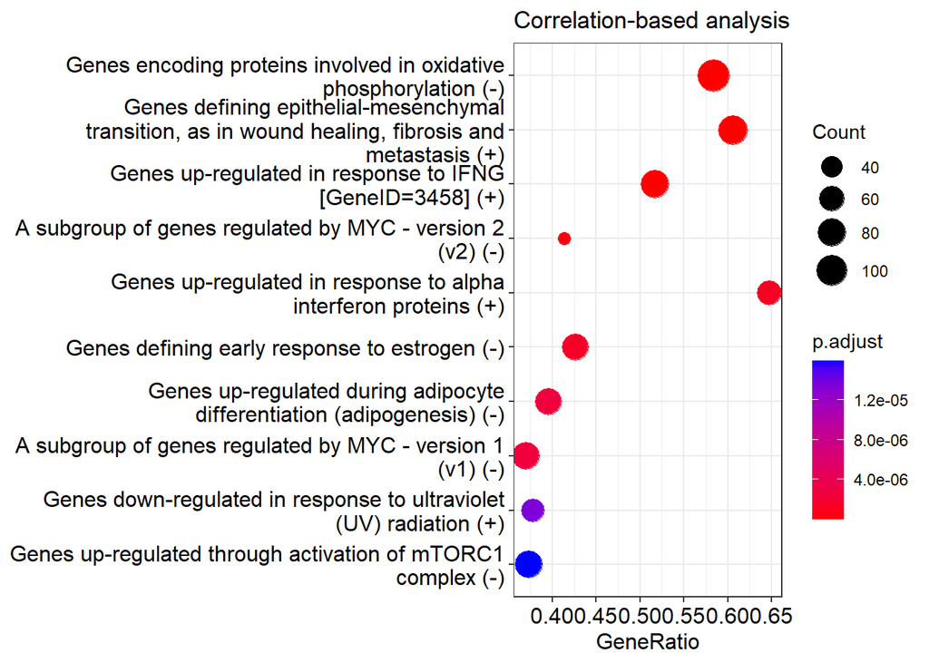

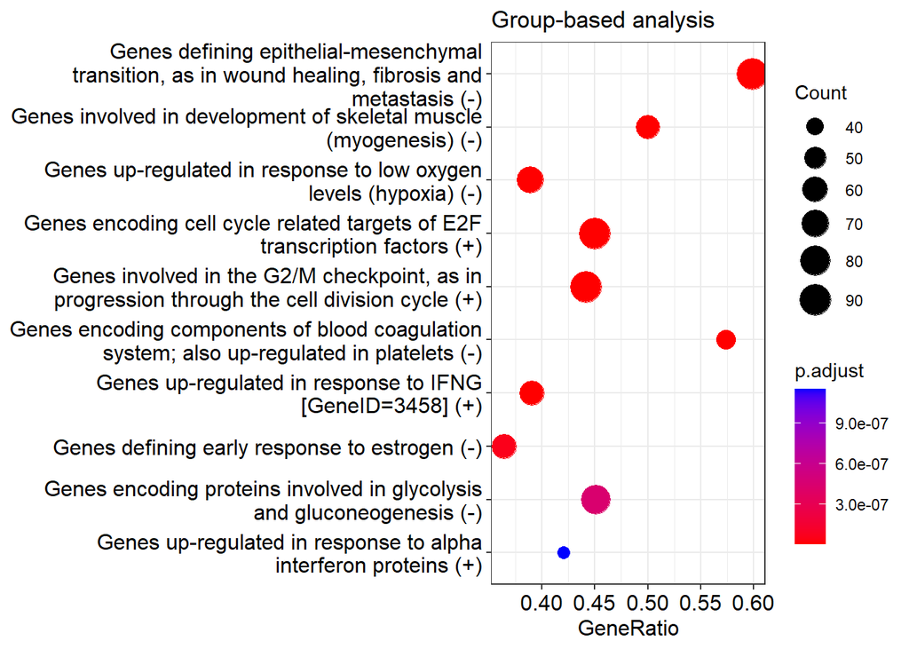

```r
dotplot.direction(gsea.cor$Hallmark, 10, label_format=50) + labs(title="Correlation-based analysis")
dotplot.direction(gsea.test$Hallmark, 10, label_format=50) + labs(title="Group-based analysis")
```

Note that the plots add a “+” or “-” sign to each gene set label to indicate enrichment at the top or bottom end of the ordered gene list, aiding in interpretation of the results. We thus observe that the Hallmark EMT gene set appears at/near the top in both analyses, but paradoxically as a positive *and* negative association of drug sensitivity. (Further investigation would reveal that enriched EMT genes have lower expression in the “responder” group, but also show overall negative correlations between expression and AUC, consistent with these results.)